# bellabeat_analysis

Lets see users in the above category

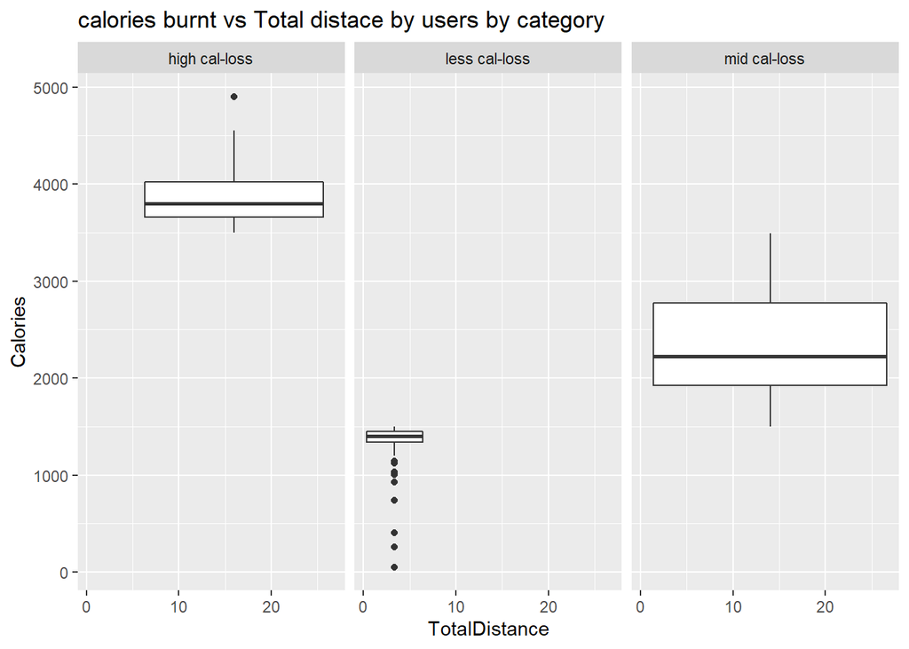

```r
calories_burn %>%
  ggplot(aes(x = TotalDistance, y = Calories)) + geom_boxplot() +
  facet_wrap(~cal_categories ) + labs(title = "calories burnt vs Total distace by users by category")
```

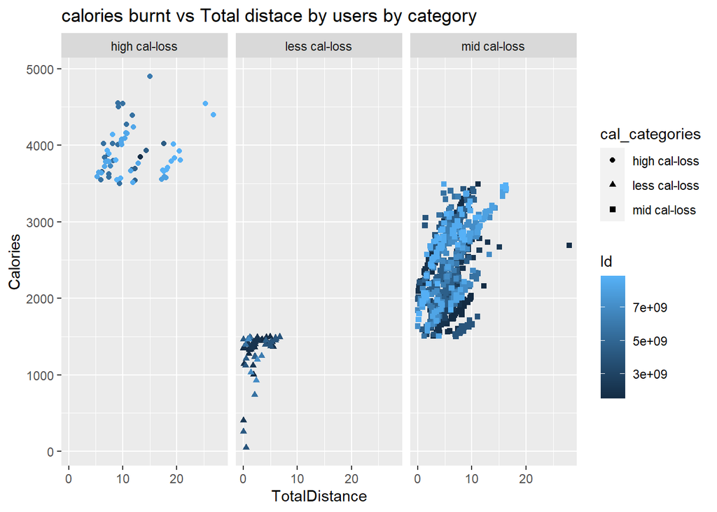

```r
calories_burn %>%
  ggplot(aes(x = TotalDistance, y = Calories, col = Id, shape = cal_categories)) + geom_point() +
  facet_wrap(~cal_categories ) + labs(title = "calories burnt vs Total distace by users by category")
```

5. Based on the boxplot graphs, it can be seen how and why some users are burning fewer calories than others. It can also be assumed based on the visuals that, users with high-calorie loss are running faster and usually covering longer distances and users in the less cal-loss category are walking less distance, and users with mid-calorie loss are walking or slow running.

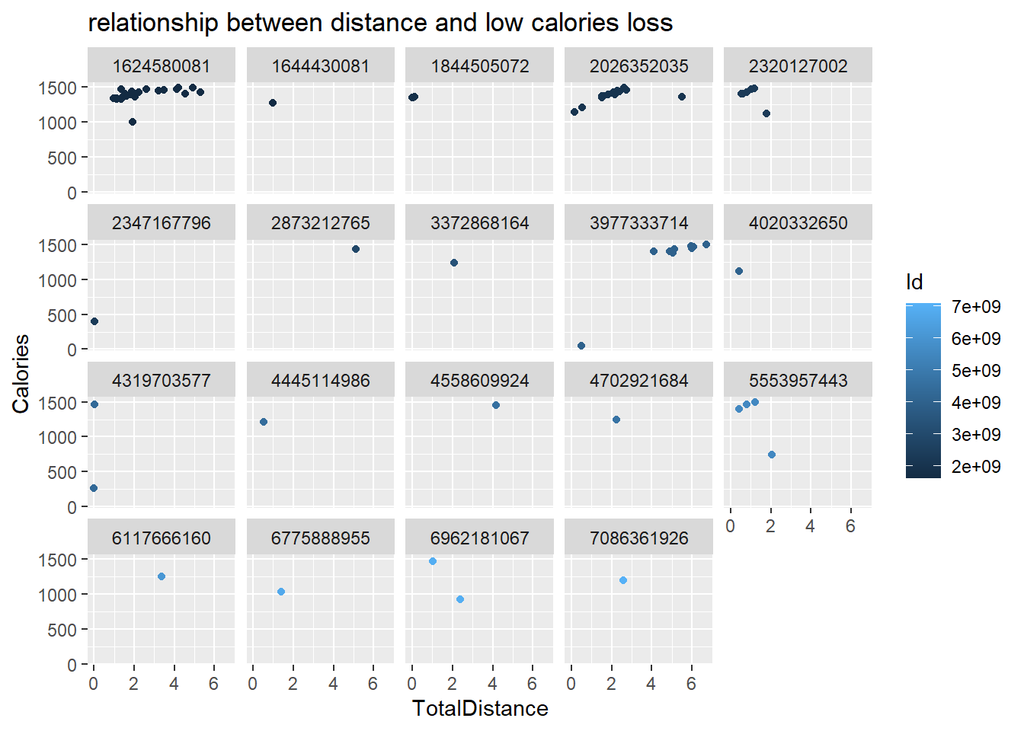

```r
less_cal_user <- calories_burn %>%
  filter(cal_categories == "less cal-loss") %>%
  group_by(cal_categories)


less_cal_user %>%
  ggplot(aes(x = TotalDistance, y = Calories, col = Id)) + geom_point() + facet_wrap(~Id) +
  labs(title = "relationship between distance and low calories loss")
```